# Pima Indians Diabetes Dataset - Exploratory Data Analysis

**Context:**

This dataset is originally from the National Institute of Diabetes and Digestive and Kidney Diseases. The objective of the dataset is to diagnostically predict whether or not a patient has diabetes, based on certain diagnostic measurements included in the dataset.

```python
from IPython.display import YouTubeVideo
YouTubeVideo("pN4HqWRybwk")
```

[video not shown]

**Data Description:**

The datasets consists of several medical predictor variables and one target variable `Outcome``.

Predictor variables includes the number of pregnancies the patient has had, their BMI, insulin level, age, and so on.

**About the data**

Numeric : Pregnancies : Number of times pregnant

Numeric : Glucose : Plasma glucose concentration at 2 hours in an oral glucose tolerance test

Numeric : BloodPressure : Diastolic blood pressure (mm Hg)

Numeric : SkinThickness : Triceps skin fold thickness (mm)

Numeric : Insulin : 2-Hour serum insulin (mu U/ml)

Numeric : BMI : Body mass index (weight in kg/(height in m)^2)

Numeric : Pedigree : Diabetes pedigree function

Numeric : Age : Age (years)

Numeric : Outcome : Class variable (0 or 1)

**Problem Statement:**

Build a machine learning model to accurately predict whether or not the patients in the dataset have diabetes or not.

To begin, we will perform an exhaustive EDA, then draw conclusions from it. In an upcoming exercise, we will fit a model to the data and actually do the prediction.

# Step 1: Read the data

**a. Import packages**

```python
import numpy as np
import pandas as pd
import matplotlib.pyplot as plt
import seaborn as sns
%matplotlib inline
sns.set(color_codes = True)
#ignore warning messages
import warnings
warnings.filterwarnings('ignore')
```

**b. Import Data**

```python
pima = pd.read_csv('./pima-indians-diabetes.csv')
```

**c. Display DataFrame**

```python
pima
```

|  | Pregnancies | Glucose | BloodPressure | SkinThickness | Insulin | BMI | DiabetesPedigreeFunction | Age | Outcome |
| --- | --- | --- | --- | --- | --- | --- | --- | --- | --- |
| 0 | 6 | 148 | 72 | 35 | 0 | 33.6 | 0.627 | 50 | 1 |
| 1 | 1 | 85 | 66 | 29 | 0 | 26.6 | 0.351 | 31 | 0 |
| 2 | 8 | 183 | 64 | 0 | 0 | 23.3 | 0.672 | 32 | 1 |
| 3 | 1 | 89 | 66 | 23 | 94 | 28.1 | 0.167 | 21 | 0 |
| 4 | 0 | 137 | 40 | 35 | 168 | 43.1 | 2.288 | 33 | 1 |
| ... | ... | ... | ... | ... | ... | ... | ... | ... | ... |
| 763 | 10 | 101 | 76 | 48 | 180 | 32.9 | 0.171 | 63 | 0 |
| 764 | 2 | 122 | 70 | 27 | 0 | 36.8 | 0.340 | 27 | 0 |
| 765 | 5 | 121 | 72 | 23 | 112 | 26.2 | 0.245 | 30 | 0 |
| 766 | 1 | 126 | 60 | 0 | 0 | 30.1 | 0.349 | 47 | 1 |
| 767 | 1 | 93 | 70 | 31 | 0 | 30.4 | 0.315 | 23 | 0 |

768 rows × 9 columns

**d. Show first 5 observations**

```python
pima.head()
```

|  | Pregnancies | Glucose | BloodPressure | SkinThickness | Insulin | BMI | DiabetesPedigreeFunction | Age | Outcome |
| --- | --- | --- | --- | --- | --- | --- | --- | --- | --- |
| 0 | 6 | 148 | 72 | 35 | 0 | 33.6 | 0.627 | 50 | 1 |
| 1 | 1 | 85 | 66 | 29 | 0 | 26.6 | 0.351 | 31 | 0 |
| 2 | 8 | 183 | 64 | 0 | 0 | 23.3 | 0.672 | 32 | 1 |
| 3 | 1 | 89 | 66 | 23 | 94 | 28.1 | 0.167 | 21 | 0 |
| 4 | 0 | 137 | 40 | 35 | 168 | 43.1 | 2.288 | 33 | 1 |

**e. Show last 5 observations**

```python
pima.tail()
```

|  | Pregnancies | Glucose | BloodPressure | SkinThickness | Insulin | BMI | DiabetesPedigreeFunction | Age | Outcome |
| --- | --- | --- | --- | --- | --- | --- | --- | --- | --- |
| 763 | 10 | 101 | 76 | 48 | 180 | 32.9 | 0.171 | 63 | 0 |
| 764 | 2 | 122 | 70 | 27 | 0 | 36.8 | 0.340 | 27 | 0 |
| 765 | 5 | 121 | 72 | 23 | 112 | 26.2 | 0.245 | 30 | 0 |
| 766 | 1 | 126 | 60 | 0 | 0 | 30.1 | 0.349 | 47 | 1 |
| 767 | 1 | 93 | 70 | 31 | 0 | 30.4 | 0.315 | 23 | 0 |

**f. Get shape of the DataFrame**

```python
pima.shape
```

```
(768, 9)
```

```python
pima.dtypes
```

```
Pregnancies                   int64
Glucose                       int64
BloodPressure                 int64
SkinThickness                 int64
Insulin                       int64
BMI                         float64
DiabetesPedigreeFunction    float64
Age                           int64
Outcome                       int64
dtype: object
```

dataset contains 768 observations and 9 variables

```python
pima.info()
```

```
<class 'pandas.core.frame.DataFrame'>
RangeIndex: 768 entries, 0 to 767
Data columns (total 9 columns):
 #   Column                    Non-Null Count  Dtype
---  ------                    --------------  -----
 0   Pregnancies               768 non-null    int64
 1   Glucose                   768 non-null    int64
 2   BloodPressure             768 non-null    int64
 3   SkinThickness             768 non-null    int64
 4   Insulin                   768 non-null    int64
 5   BMI                       768 non-null    float64
 6   DiabetesPedigreeFunction  768 non-null    float64
 7   Age                       768 non-null    int64
 8   Outcome                   768 non-null    int64
dtypes: float64(2), int64(7)
memory usage: 54.1 KB
```

This preliminary study shows that

- there are 768 entries and 9 columns.
- there are no null values in any of the variable.

But there are values for some columns that do not make sense---they are marked as a zero (0) value.

For example, a zero value in `BloodPressure` variable does not make sense.

Also there are zero values in `Glucose`, `SkinThickness`, `Insulin`, and `BMI` variables.

These are actually **missing values**, a phenomenon that commonly occurs in experimental data gathering.

We can also verify the existence of any null values using the following:

```python
pima.isnull().values.any()
```

```
False
```

```python
pima.describe().T
```

|  | count | mean | std | min | 25% | 50% | 75% | max |
| --- | --- | --- | --- | --- | --- | --- | --- | --- |
| Pregnancies | 768.0 | 3.845052 | 3.369578 | 0.000 | 1.00000 | 3.0000 | 6.00000 | 17.00 |
| Glucose | 768.0 | 120.894531 | 31.972618 | 0.000 | 99.00000 | 117.0000 | 140.25000 | 199.00 |
| BloodPressure | 768.0 | 69.105469 | 19.355807 | 0.000 | 62.00000 | 72.0000 | 80.00000 | 122.00 |
| SkinThickness | 768.0 | 20.536458 | 15.952218 | 0.000 | 0.00000 | 23.0000 | 32.00000 | 99.00 |
| Insulin | 768.0 | 79.799479 | 115.244002 | 0.000 | 0.00000 | 30.5000 | 127.25000 | 846.00 |
| BMI | 768.0 | 31.992578 | 7.884160 | 0.000 | 27.30000 | 32.0000 | 36.60000 | 67.10 |
| DiabetesPedigreeFunction | 768.0 | 0.471876 | 0.331329 | 0.078 | 0.24375 | 0.3725 | 0.62625 | 2.42 |
| Age | 768.0 | 33.240885 | 11.760232 | 21.000 | 24.00000 | 29.0000 | 41.00000 | 81.00 |
| Outcome | 768.0 | 0.348958 | 0.476951 | 0.000 | 0.00000 | 0.0000 | 1.00000 | 1.00 |

This table of summary statistics tells us following:

For example; let us take 'Pregnancies` variable

1. count: Total number of entries or rows = 768 (no missing values)
2. mean: Sum of all values of Pregnancies divided by 768 = 3.845052
3. std: Standard Deviation - measures how far data values are from their mean = 3.369578
4. min: Minimum number of pregnancy = 0
5. 25%: First Quartile (Q1) = 1
6. 50%: Second Quartile (Q2) = 3
7. 75%: Third Quartile (Q3) = 6
8. max: Maximum number of pregnancies = 17

The 5-number summary can be better explained using boxplots---see below.

We want to predict whether or not the patients in the dataset have diabetes or not?

So let us check how many people have diabetes and how many of them do not.

```python
pima['Outcome'].value_counts()
```

```
0    500
1    268
Name: Outcome, dtype: int64
```

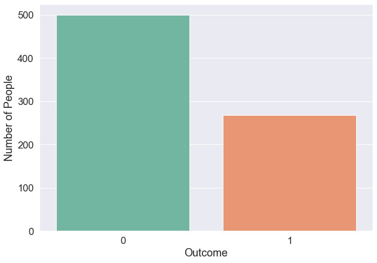

```python
plt.figure(figsize=(10,7))
sns.set(font_scale = 1.5)
sns.countplot(x = 'Outcome', data=pima, palette="Set2")
plt.ylabel('Number of People')
plt.show()
```

We can see from above plot that:

- 500 subjects do not have diabetes
- 268 subjects have diabetes

Another way to depict this, is using a pie-chart.

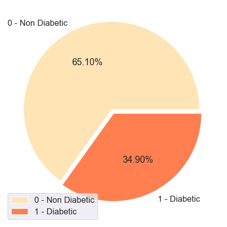

```python
plt.figure(figsize=(8,8))
pieC = pima['Outcome'].value_counts()
explode = (0.05, 0)
colors = ['moccasin', 'coral']
labels = ['0 - Non Diabetic', '1 - Diabetic']
sns.set(font_scale = 1.5)
plt.pie(pieC, labels = ('0 - Non Diabetic', '1 - Diabetic'), autopct = "%.2f%%", explode = explode, colors = colors)
plt.legend(labels, loc = 'lower left')
plt.show()
```

We can see from above pie plot that:

- 65.10% out of 768 Pima Indian women do not have diabetes
- 34.90% out of 768 Pima Indian women have diabetes

# Step 2: Exploratory Data Analysis (EDA)

**a. MISSING VALUES**

There are variables that have a minimum value of zero (0). For some variables, a value of zero does not make sense and thus indicates a **missing value**.

The following variables have an invalid zero value:

1. `BloodPressure`
2. `Glucose`
3. `SkinThickness`
4. `Insulin`
5. `BMI`

**Count of missing values (zeros) in above-mentioned 5 variables**

```python
pima[pima['Glucose'] == 0]
```

|  | Pregnancies | Glucose | BloodPressure | SkinThickness | Insulin | BMI | DiabetesPedigreeFunction | Age | Outcome |
| --- | --- | --- | --- | --- | --- | --- | --- | --- | --- |
| 75 | 1 | 0 | 48 | 20 | 0 | 24.7 | 0.140 | 22 | 0 |
| 182 | 1 | 0 | 74 | 20 | 23 | 27.7 | 0.299 | 21 | 0 |
| 342 | 1 | 0 | 68 | 35 | 0 | 32.0 | 0.389 | 22 | 0 |
| 349 | 5 | 0 | 80 | 32 | 0 | 41.0 | 0.346 | 37 | 1 |
| 502 | 6 | 0 | 68 | 41 | 0 | 39.0 | 0.727 | 41 | 1 |

```python
missingPlas = pima[pima['Glucose'] == 0].shape[0]
print ("Number of zeros in variable Plas (Glucose): ", missingPlas)
```

```
Number of zeros in variable Plas (Glucose):  5
```

```python
missingPres = pima[pima['BloodPressure'] == 0].shape[0]
print ("Number of zeros in variable Pres (BloodPressure): ", missingPres)
```

```
Number of zeros in variable Pres (BloodPressure):  35
```

```python
missingSkin = pima[pima['SkinThickness'] == 0].shape[0]
print ("Number of zeros in variable Skin (SkinThickness): ", missingSkin)
```

```
Number of zeros in variable Skin (SkinThickness):  227
```

```python
missingTest = pima[pima['Insulin'] == 0].shape[0]
print ("Number of zeros in variable Test (Insulin): ", missingTest)
```

```
Number of zeros in variable Test (Insulin):  374
```

```python
missingMass = pima[pima['BMI'] == 0].shape[0]
print ("Number of zeros in variable Mass (BMI): ", missingMass)
```

```
Number of zeros in variable Mass (BMI):  11
```

**Another method to calculate total number of zeros in a column**

Replace zero (0) values with NaN values and then sum the NaN values in each column to get a count of NaN values.

```python
pima_copy = pima.copy(deep = True)
```

```python
pima_copy[['Glucose','BloodPressure','SkinThickness','Insulin','BMI']] = pima_copy[['Glucose','BloodPressure','SkinThickness','Insulin','BMI']].replace(0,np.NaN)
print(pima_copy.isnull().sum())
```

```
Pregnancies                   0
Glucose                       5
BloodPressure                35
SkinThickness               227
Insulin                     374
BMI                          11
DiabetesPedigreeFunction      0
Age                           0
Outcome                       0
dtype: int64
```

**b. Visualization for understanding and analysing the distribution of data for different variables**

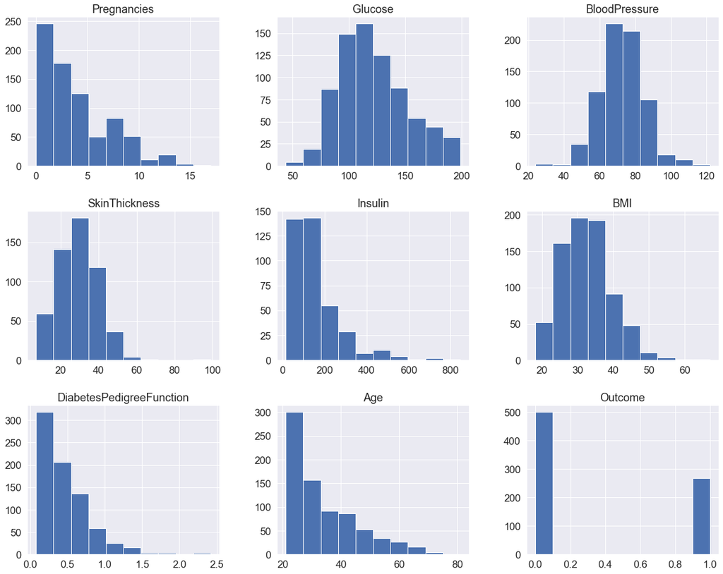

```python
pima_copy.hist(figsize = (20,16),grid=True)
plt.show()
```

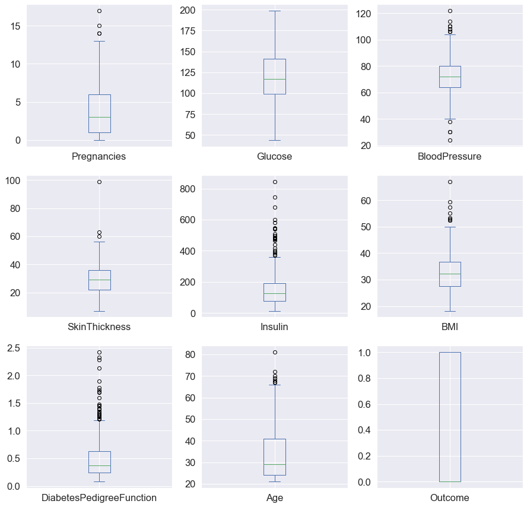

```python
pima_copy.plot(kind= 'box' , subplots=True, layout=(3,3), sharex=False, sharey=False, figsize=(15,15))
sns.set(font_scale = 1.5)
```

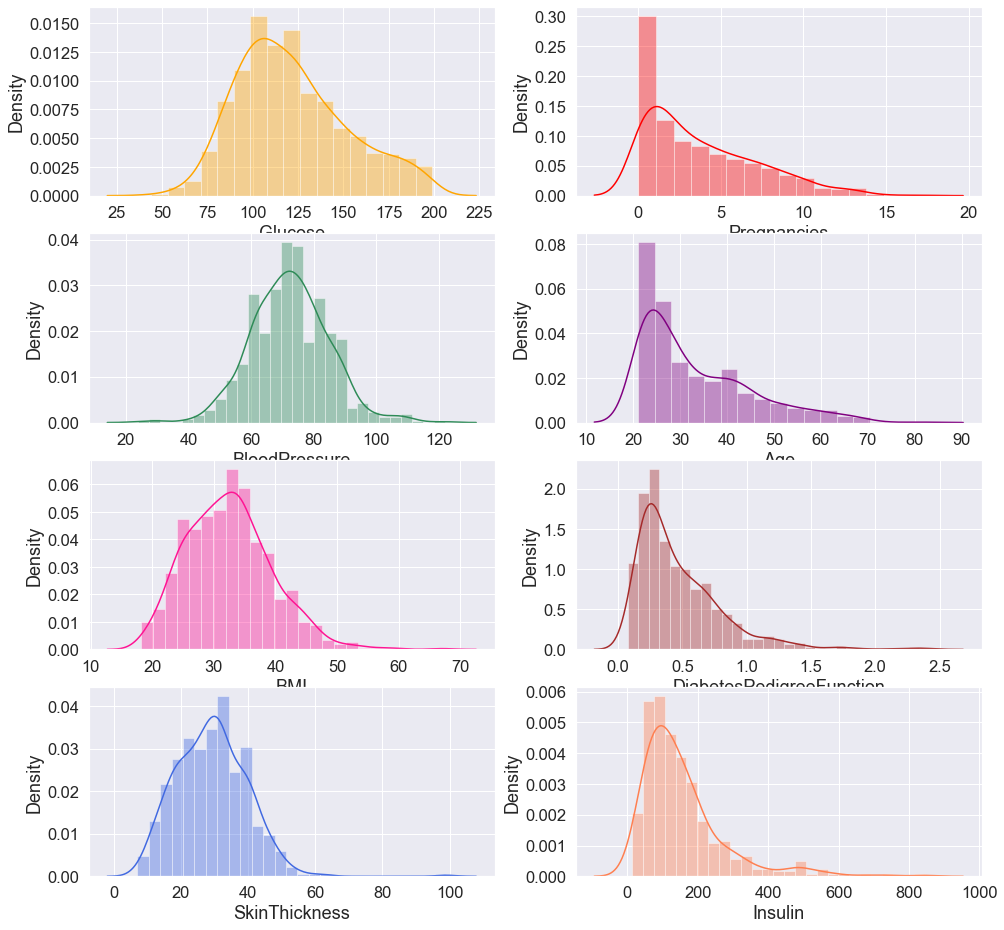

```python
fig, ax = plt.subplots(4,2, figsize=(16,16))
sns.set(font_scale = 1)
sns.distplot(pima_copy.Glucose, ax = ax[0,0], color = 'orange')
sns.distplot(pima_copy.Pregnancies, ax = ax[0,1], color = 'red')
sns.distplot(pima_copy.BloodPressure, ax = ax[1,0], color = 'seagreen')
sns.distplot(pima_copy.Age, ax = ax[1,1], color = 'purple')
sns.distplot(pima_copy.BMI, ax = ax[2,0], color = 'deeppink')
sns.distplot(pima_copy.DiabetesPedigreeFunction, ax = ax[2,1], color = 'brown')
sns.distplot(pima_copy.SkinThickness, ax = ax[3,0], color = 'royalblue')
sns.distplot(pima_copy.Insulin, ax = ax[3,1], color = 'coral')
plt.show()
```

### Observation

Several variables have right-skewed, asymmetric distributions.

- Age,
- DiabetesPedigreeFunction,
- Pregnancies),
- SkinThickness,
- Insulin.

This means that the Mean > Median.

**c. DATA CLEANING**

We now check:

- the distributions for those variables that have an invalid zero value
- the presence of "outliers"
- the symmetry of the distributions (normal, left-skewed or right-skewed )

For this, we will use

- boxplot
- distplot (Histogram)

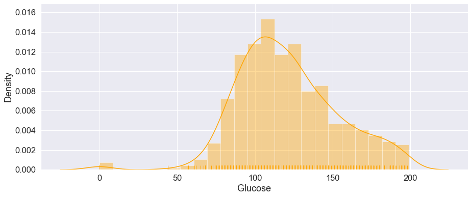

```python
plt.figure(figsize=(15,6))
sns.set(font_scale = 1.5)
sns.distplot(pima['Glucose'], kde = True, rug = True, color = 'orange')
plt.show()
```

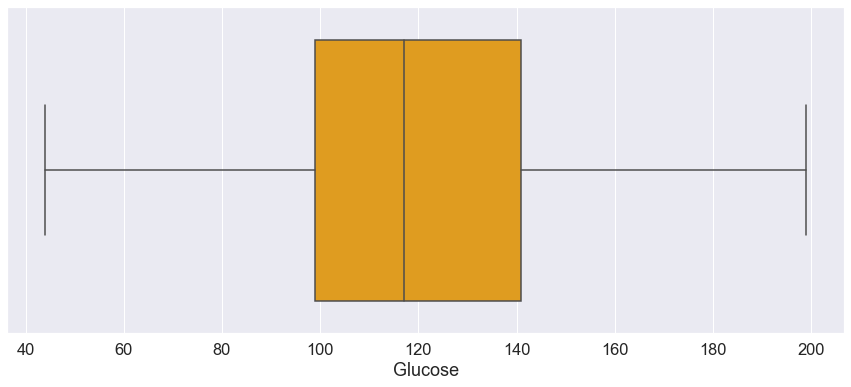

```python
plt.figure(figsize=(15,6))
sns.set(font_scale = 1.5)
sns.boxplot(pima_copy.Glucose, color = 'orange')
plt.show()
```

The variable `Glucose` does not have any outliers.

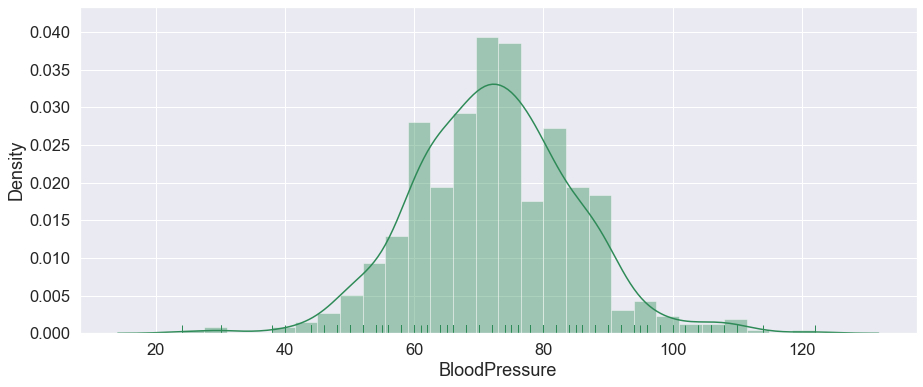

```python
plt.figure(figsize=(15,6))
sns.set(font_scale = 1.5)
sns.distplot(pima_copy['BloodPressure'], kde = True, rug = True, color = 'seagreen')
plt.show()
```

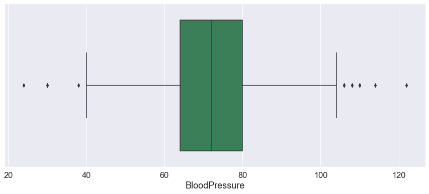

```python
plt.figure(figsize=(15,6))
sns.set(font_scale = 1.5)
sns.boxplot(pima_copy.BloodPressure, color = 'seagreen')
plt.show()
```

Variable 'Pres' [BloodPressure] has a number of outliers.

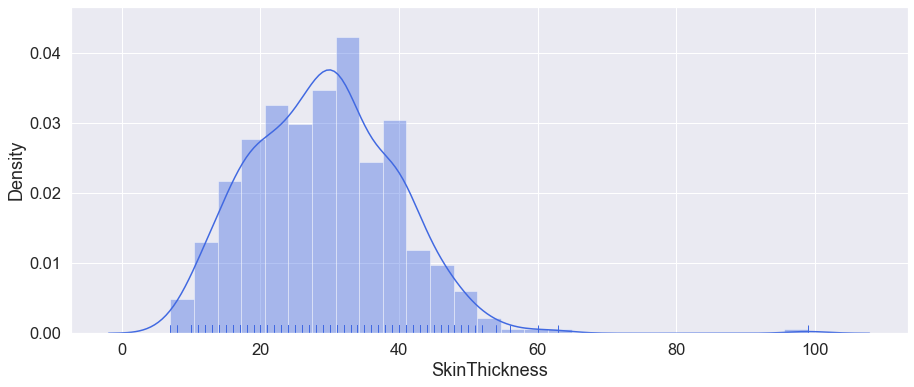

```python
plt.figure(figsize=(15,6))
sns.set(font_scale = 1.5)
sns.distplot(pima_copy['SkinThickness'], kde = True, rug = True, color = 'royalblue')
plt.show()
```

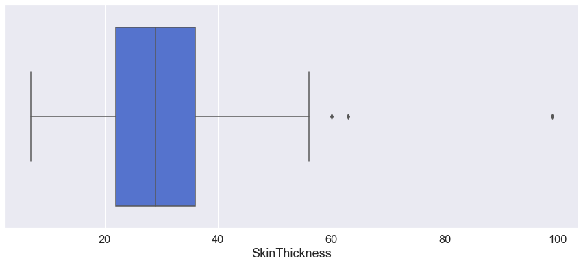

```python
plt.figure(figsize=(15,6))
sns.set(font_scale = 1.5)
sns.boxplot(pima_copy.SkinThickness, color = 'royalblue')
plt.show()
```

`SkinThickness` 3 outliers with large values.

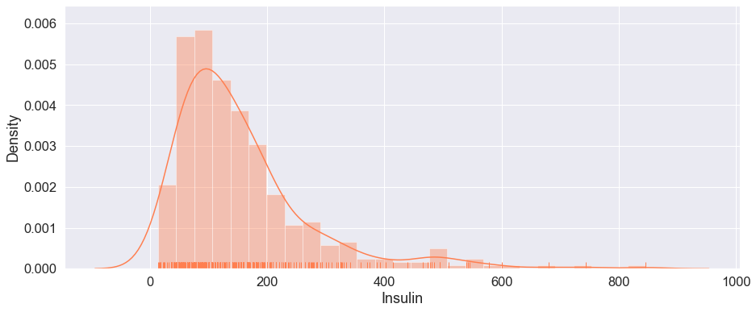

```python
plt.figure(figsize=(15,6))
sns.set(font_scale = 1.5)
sns.distplot(pima_copy['Insulin'], kde = True, rug = True, color = 'coral')
plt.show()
```

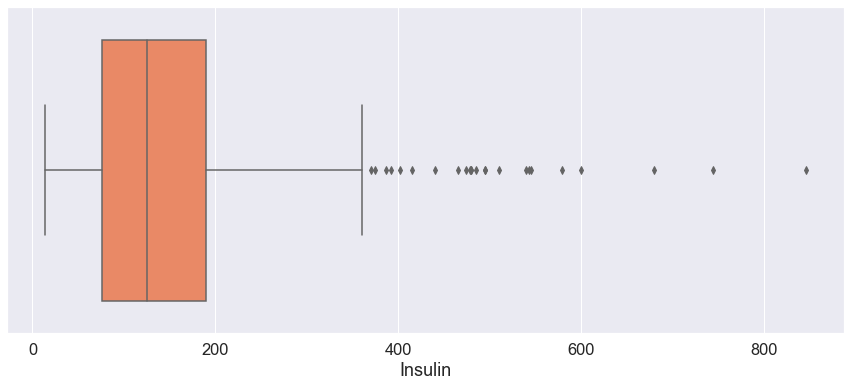

```python
plt.figure(figsize=(15,6))
sns.set(font_scale = 1.5)
sns.boxplot(pima_copy.Insulin, color = 'coral')
plt.show()
```

The variable `Insulin` has many outliers, with very large vlaues.

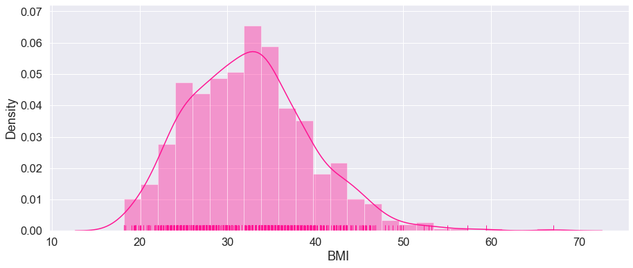

```python
plt.figure(figsize=(15,6))
sns.set(font_scale = 1.5)
sns.distplot(pima_copy['BMI'], kde = True, rug = True, color = 'deeppink')
plt.show()
```

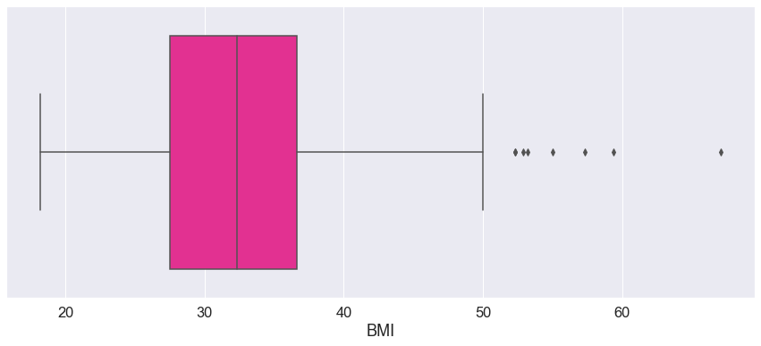

```python
plt.figure(figsize=(15,6))
sns.set(font_scale = 1.5)
sns.boxplot(pima_copy.BMI, color = 'deeppink')
plt.show()
```

Once again, there are numerous outliers with large values.

Given the large number of NaN vlaues, it is higly recommended to replace them with a Median or a Mean.

- Variables `Glucose` and `BloodPressure` do not have many outliers and we will fill them with their mean values
- Variables `SkinThickness`, `Insulin`, and `BMI` have much disparity, we need to fill more data, so the median is recommended here.

```python
pima_copy['Glucose'].fillna(pima_copy['Glucose'].mean(), inplace = True)
pima_copy['BloodPressure'].fillna(pima_copy['BloodPressure'].mean(), inplace = True)
pima_copy['SkinThickness'].fillna(pima_copy['SkinThickness'].median(), inplace = True)
pima_copy['Insulin'].fillna(pima_copy['Insulin'].median(), inplace = True)
pima_copy['BMI'].fillna(pima_copy['BMI'].median(), inplace = True)
# check:
print(pima_copy.isnull().sum())
```

```
Pregnancies                 0
Glucose                     0
BloodPressure               0
SkinThickness               0
Insulin                     0
BMI                         0
DiabetesPedigreeFunction    0
Age                         0
Outcome                     0
dtype: int64
```

### Conclusion

We have replaced all NaN values with Mean or Median, and the data is now "clean"

```python
pima_copy.describe().T
```

|  | count | mean | std | min | 25% | 50% | 75% | max |
| --- | --- | --- | --- | --- | --- | --- | --- | --- |
| Pregnancies | 768.0 | 3.845052 | 3.369578 | 0.000 | 1.00000 | 3.000000 | 6.00000 | 17.00 |
| Glucose | 768.0 | 121.686763 | 30.435949 | 44.000 | 99.75000 | 117.000000 | 140.25000 | 199.00 |
| BloodPressure | 768.0 | 72.405184 | 12.096346 | 24.000 | 64.00000 | 72.202592 | 80.00000 | 122.00 |
| SkinThickness | 768.0 | 29.108073 | 8.791221 | 7.000 | 25.00000 | 29.000000 | 32.00000 | 99.00 |
| Insulin | 768.0 | 140.671875 | 86.383060 | 14.000 | 121.50000 | 125.000000 | 127.25000 | 846.00 |
| BMI | 768.0 | 32.455208 | 6.875177 | 18.200 | 27.50000 | 32.300000 | 36.60000 | 67.10 |
| DiabetesPedigreeFunction | 768.0 | 0.471876 | 0.331329 | 0.078 | 0.24375 | 0.372500 | 0.62625 | 2.42 |
| Age | 768.0 | 33.240885 | 11.760232 | 21.000 | 24.00000 | 29.000000 | 41.00000 | 81.00 |
| Outcome | 768.0 | 0.348958 | 0.476951 | 0.000 | 0.00000 | 0.000000 | 1.00000 | 1.00 |

**d. VISUALIZATION**

Let us perform visualization on the **clean data (pima_copy)**

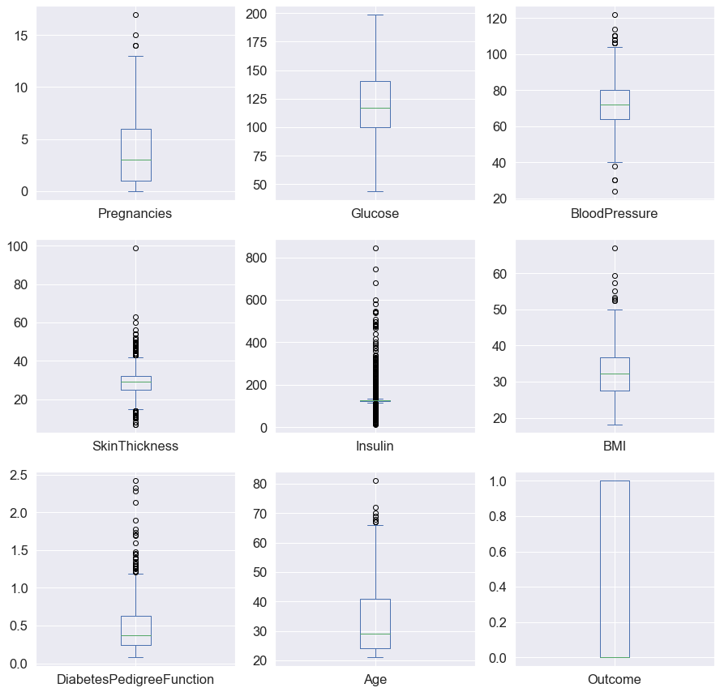

```python
pima_copy.plot(kind= 'box' , subplots=True, layout=(3,3), sharex=False, sharey=False, figsize=(15,15))
sns.set(font_scale = 1.5)
```

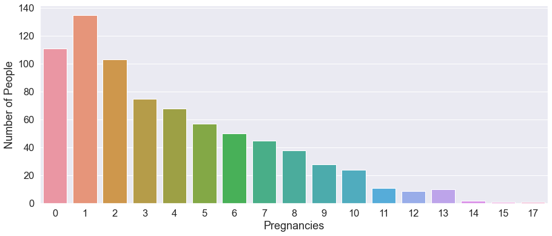

```python
plt.figure(figsize=(15,6))
sns.set(font_scale = 1.5)
sns.countplot(pima_copy['Pregnancies'])
plt.ylabel('Number of People')
plt.show()
```

This plot describes No. of Pregnancies vs No. of Pima Indian Women

Let us calculate the average and median of the number of children had by Pima Indian women

```python
print("Average number of children had by Pima women: ", pima_copy['Pregnancies'].mean())
```

```
Average number of children had by Pima women:  3.8450520833333335
```

```python
pima_copy['Pregnancies'].median()
```

```
3.0
```

```python
preg = pima_copy[pima_copy['Pregnancies'] >= 1].shape[0]
print('Number of Pima Women who had children: ', preg)
```

```
Number of Pima Women who had children:  657
```

```python
notPreg = pima_copy[pima_copy['Pregnancies'] == 0].shape[0]
print('Number of Pima women who did not have children: ', notPreg)
```

```
Number of Pima women who did not have children:  111
```

```python
pregPlusDiabetes = pima_copy[(pima_copy['Pregnancies'] >= 1) & (pima_copy['Outcome'] == 1)].shape[0]
print('Number of women who have children and are diabetic: ',pregPlusDiabetes)
```

```
Number of women who have children and are diabetic:  230
```

```python
pregPlusNotDiabetes = pima_copy[(pima_copy['Pregnancies'] >= 1) & (pima_copy['Outcome'] == 0)].shape[0]
print('Number of women who have children and are not diabetic: ',pregPlusNotDiabetes)
```

```
Number of women who have children and are not diabetic:  427
```

```python
notPregPlusDiabetes = pima_copy[(pima_copy['Pregnancies'] == 0) & (pima_copy['Outcome'] == 1)].shape[0]
print('Number of women who do not have children and are diabetic: ',notPregPlusDiabetes)
```

```
Number of women who do not have children and are diabetic:  38
```

```python
notPregPlusNotDiabetes = pima_copy[(pima_copy['Pregnancies'] == 0) & (pima_copy['Outcome'] == 0)].shape[0]
print('Number of women who do not have children and are not diabetic: ',notPregPlusNotDiabetes)
```

```
Number of women who do not have children and are not diabetic:  73
```

#### Conclusion

**e. BIVARIATE ANALYSIS**

The calculation of the correlation matrix, often performed in EDA, will give indications of relations between the variables, two-by-two.

```python
corr = pima_copy.corr()
corr
```

|  | Pregnancies | Glucose | BloodPressure | SkinThickness | Insulin | BMI | DiabetesPedigreeFunction | Age | Outcome |
| --- | --- | --- | --- | --- | --- | --- | --- | --- | --- |
| Pregnancies | 1.000000 | 0.127911 | 0.208522 | 0.081770 | 0.025047 | 0.021559 | -0.033523 | 0.544341 | 0.221898 |
| Glucose | 0.127911 | 1.000000 | 0.218367 | 0.192686 | 0.419064 | 0.231128 | 0.137060 | 0.266534 | 0.492928 |
| BloodPressure | 0.208522 | 0.218367 | 1.000000 | 0.191853 | 0.045087 | 0.281199 | -0.002763 | 0.324595 | 0.166074 |
| SkinThickness | 0.081770 | 0.192686 | 0.191853 | 1.000000 | 0.155610 | 0.543205 | 0.102188 | 0.126107 | 0.214873 |
| Insulin | 0.025047 | 0.419064 | 0.045087 | 0.155610 | 1.000000 | 0.180241 | 0.126503 | 0.097101 | 0.203790 |
| BMI | 0.021559 | 0.231128 | 0.281199 | 0.543205 | 0.180241 | 1.000000 | 0.153438 | 0.025597 | 0.312038 |
| DiabetesPedigreeFunction | -0.033523 | 0.137060 | -0.002763 | 0.102188 | 0.126503 | 0.153438 | 1.000000 | 0.033561 | 0.173844 |
| Age | 0.544341 | 0.266534 | 0.324595 | 0.126107 | 0.097101 | 0.025597 | 0.033561 | 1.000000 | 0.238356 |
| Outcome | 0.221898 | 0.492928 | 0.166074 | 0.214873 | 0.203790 | 0.312038 | 0.173844 | 0.238356 | 1.000000 |

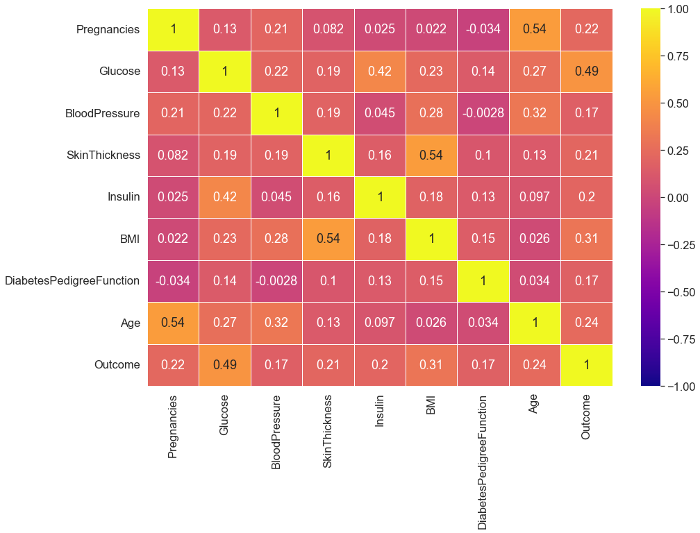

```python
plt.figure(figsize=(15,10))
sns.set(font_scale = 1.5)
sns.heatmap(corr, annot = True, cmap = 'plasma', vmin = -1, vmax = 1, linecolor='white', linewidths= 1)
plt.show()
```

**From the above heatmap, we can conclude the following:**

1. There is no feature variable that has a strong correlation with the target `Outcome` as there is no value greater than +0.70, which would indicate a strong uphill (positive) linear relationship.
2. The best predictor of the target variable `Outcome` is `Glucose` --> 0.49 which is near to 0.50 which indicates a moderate uphill (positive) relationship.
3. The second best predictor of target variable `Outcome` is `BMI` --> 0.31 which indicates a weak uphill (positive) linear relationship.
4. The correlation between `BMI` and `SkinThickness` is 0.54 which indicates that BMI increases with an increase in Skin Thickness.
5. Correlation between `Age` and `Pregnancies` is 0.54 which indicates that an increase in age increases the chances of having a child.
6. All the variables are somewhat correlated. So we cannot eliminate any variable just by looking at the correlation matrix.
7. The effects of causality can be evaluated using **partial correlations** that attempt to eliminate confounding variables...

```python
print('Average Glucose for Pima woman who has diabetes: ', pima_copy[pima_copy['Outcome'] == 1]['Glucose'].mean())
```

```
Average Glucose for Pima woman who has diabetes:  142.16557285655603
```

```python
print('Average Glucose for Pima woman who does not have diabetes: ', pima_copy[pima_copy['Outcome'] == 0]['Glucose'].mean())
```

```
Average Glucose for Pima woman who does not have diabetes:  110.71012057667103
```

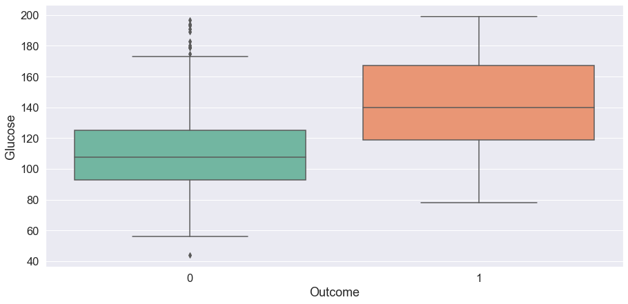

```python
plt.figure(figsize=(15,7))
sns.boxplot(pima_copy['Outcome'],pima_copy['Glucose'], palette="Set2")
sns.set(font_scale = 1.5)
```

Clearly,

- Pima women who have diabetes have higher Glucose levels, whereas
- Pima women who do not have diabetes have lower Glucose levels.

```python
print('Average BMI for Pima woman who has diabetes: ', pima_copy[pima_copy['Outcome'] == 1]['BMI'].mean())
```

```
Average BMI for Pima woman who has diabetes:  35.38358208955219
```

```python
print('Average BMI for Pima woman who does not have diabetes: ', pima_copy[pima_copy['Outcome'] == 0]['BMI'].mean())
```

```
Average BMI for Pima woman who does not have diabetes:  30.885599999999958
```

From the Internet, here is the BMI scale:

- Underweight: BMI is less than 18.5
- Normal weight: BMI is 18.5 to 24.9
- Overweight: BMI is 25 to 29.9

Thus we can conclude that Pima women are Obese, both those who have diabetes and those who do not, as their average BMI is more than 30.

A Pima woman who has diabetes has a greater BMI compared to one who does not have diabetes.

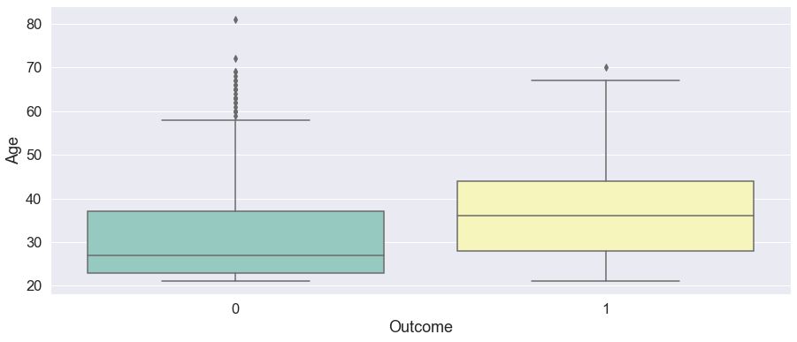

```python
plt.figure(figsize=(15,6))
sns.set(font_scale = 1.5)
sns.boxplot(pima_copy['Outcome'],pima_copy['Age'], palette = "Set3")
plt.show()
```

```python
oneOutcome = pima_copy[pima_copy['Outcome'] == 1]
print("Minimum age of Pima woman who has Diabetes: ",oneOutcome['Age'].min())
```

```
Minimum age of Pima woman who has Diabetes:  21
```

```python
print("Maximum age of Pima woman who has Diabetes: ",oneOutcome['Age'].max())
```

```
Maximum age of Pima woman who has Diabetes:  70
```

```python
zeroOutcome = pima_copy[pima_copy['Outcome'] == 0]
print("Minimum age of Pima woman who does not have Diabetes: ",zeroOutcome['Age'].min())
```

```
Minimum age of Pima woman who does not have Diabetes:  21
```

```python
zeroOutcome = pima_copy[pima_copy['Outcome'] == 0]
print("Maximum age of Pima woman who does not have Diabetes: ",zeroOutcome['Age'].max())
```

```
Maximum age of Pima woman who does not have Diabetes:  81
```

```python
print('Average Age of Pima woman who has diabetes: ',pima_copy[pima_copy['Outcome'] == 1]['Age'].mean())
```

```
Average Age of Pima woman who has diabetes:  37.06716417910448
```

```python
print('Average Age of Pima woman who does not have diabetes: ',pima_copy[pima_copy['Outcome'] == 0]['Age'].mean())
```

```
Average Age of Pima woman who does not have diabetes:  31.19
```

#### Observation

As age increases the risk of having diabetes also increases

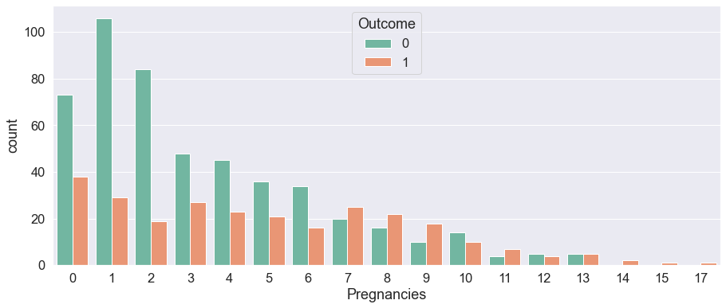

```python
plt.figure(figsize=(15,6))
sns.set(font_scale = 1.5)
sns.countplot(x = 'Pregnancies', hue = 'Outcome', data = pima_copy, palette = 'Set2')
plt.show()
```

There is much less correlation between `Pregnancies` and `Outcome`. That is, they are weakly correlated.

Pima woman with a smaller number of children have a low probability of diabetes.

```python
print('Average Skin Thickness of Pima woman who has diabetes: ', pima_copy[pima_copy['Outcome'] == 1]['SkinThickness'].mean())
```

```
Average Skin Thickness of Pima woman who has diabetes:  31.686567164179106
```

```python
print('Average Skin Thickness of Pima woman who does not have diabetes: ', pima_copy[pima_copy['Outcome'] == 0]['SkinThickness'].mean())
```

```
Average Skin Thickness of Pima woman who does not have diabetes:  27.726
```

But we can say that greater the skin thickness, the higher is the probability of getting diabetes.

```python
print('Average Insulin of Pima woman who has diabetes: ', pima_copy[pima_copy['Outcome'] == 1]['Insulin'].mean())
```

```
Average Insulin of Pima woman who has diabetes:  164.70149253731344
```

```python
print('Average Insulin of Pima woman who does not have diabetes: ', pima_copy[pima_copy['Outcome'] == 0]['Insulin'].mean())
```

```
Average Insulin of Pima woman who does not have diabetes:  127.792
```

Just like 'SkinThickness', for 'Insulin', we replaced invalid zero minimum value with the median so the data is not representative.

But we can say that the higher the insulin level, the higher are the chances of getting diabetes.

Also insulin has a moderate correlation with Glucose.

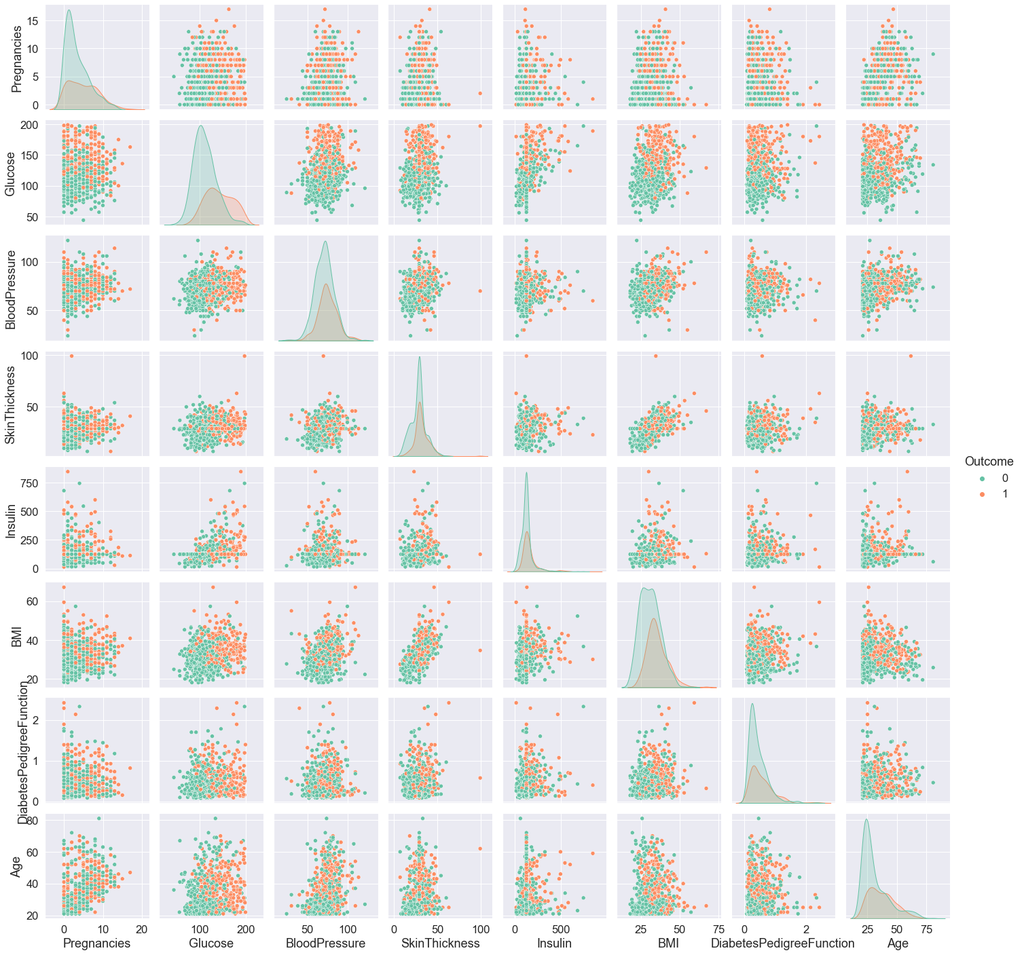

```python
sns.set(font_scale = 1.5)
sns.pairplot(data = pima_copy, hue = 'Outcome', diag_kind = 'kde', palette = 'Set2')
plt.show()
```

**Analysis**

1. The diagonal shows the distribution of the the dataset with the kernel density plots.
2. The scatter-plots show the relation between each and every attribute or feature, taken pairwise. Looking at the scatter-plots, we can say that no two attributes are able to clearly seperate the two outcome-classes.

# Step 3: Build a machine learning Model

We would like to build a predictive model so that when a new person walks-in with these values of the variables, we can feed them to the model and the model will tell us what is the probability of 0 or 1

We will use **"Logistic Regression"** and **"Naive Bayes classifier"** algorithm to predict 0 or 1. This will be done in a forthcoming exercise.